# Data Analytics Project

By Mateusz Ulinski, Roberta Namo, and Leszek Olko

## Irish Crime Statistics

This project is based on the Crimes per Garda Station dataset, which shows the different crimes at each Garda station in Ireland, between the years 2004 and 2016.

### Questions

From this dataset we want to find out

- Does the number of controlled drug offences correlate to the number of other crimes?
- For each area, what is the most popular crime?
- Is the amount of crime going up or down in different areas?
- Overall, is the amount of crime going up or down?
- Which year had the highest amount of crime

### Dataset

The nominal variables in our dataset are:

- Station
- Division

The rest of the variables are inverval, each of these can be seen for every year from 2004 to 2016

- Attempts to threat or murder
- Dangerous or negligent acts
- Kidnapping and related offences
- Robbery extortion and hijacking
- Burglary and related offences
- Theft and related offences
- Fraud and deception offences
- Controller drug offences
- Weapons and explosive offences
- Damage to property and to the environement
- Public order and other social code offences
- Offences against government, justice procedures and organisation of crimes

## Descriptive Statistics

### Murders 2004~2016

Let’s take a look at the *Attempts or threats to murder, assaults, hrassments and related offences* data from 2004

```
##    Min. 1st Qu.  Median    Mean 3rd Qu.    Max.
##    0.00    3.00    8.00   23.58   23.00  429.00
```

And the same from 2016

```
##    Min. 1st Qu.  Median    Mean 3rd Qu.    Max.
##   0.000   0.000   2.000   6.853   6.000 158.000
```

From this we can see that there’s been an overall decrease in that specific category over the 12 year period.

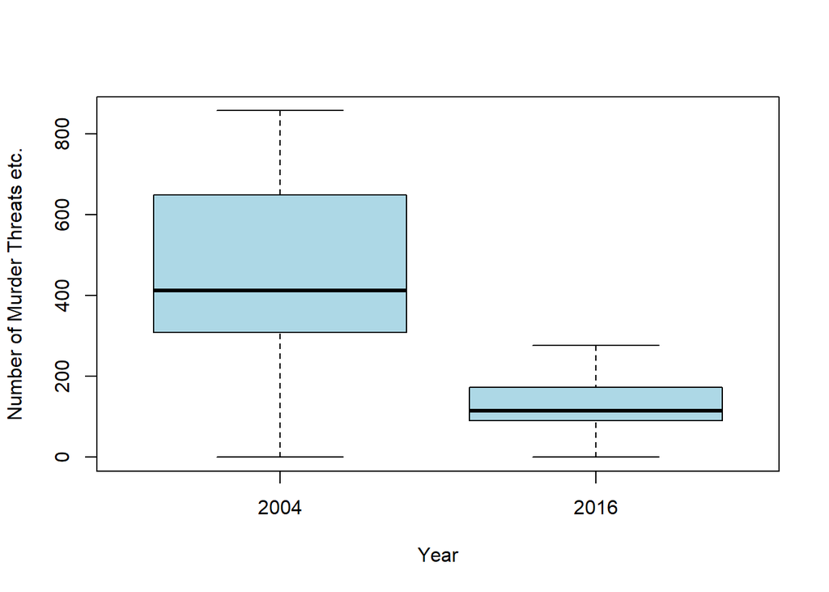

## Task 5

### Freqency Histogram

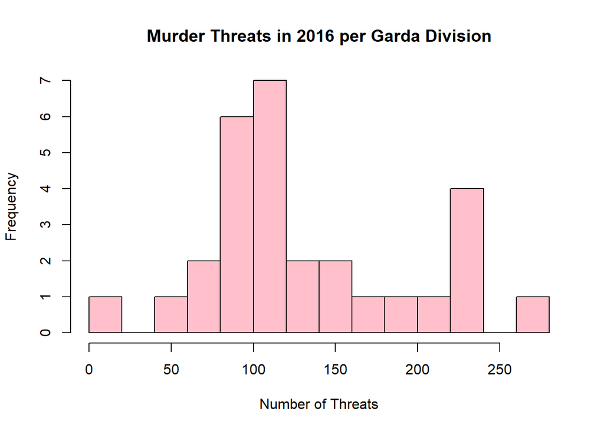

### Density Plot

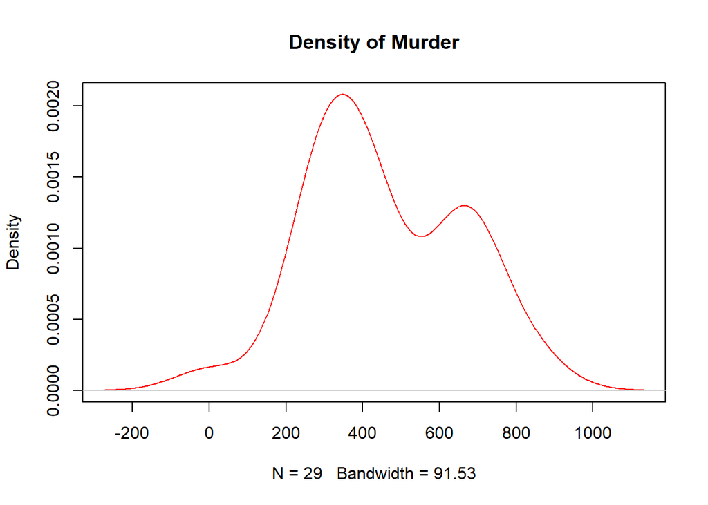

```r
plot(density(murders.2004$number.of.threats), main="Density of Murder", col="red", type="l")
```

### Pie Chart

Lets take a look at all crimes in 2010 and see which one was the most popular

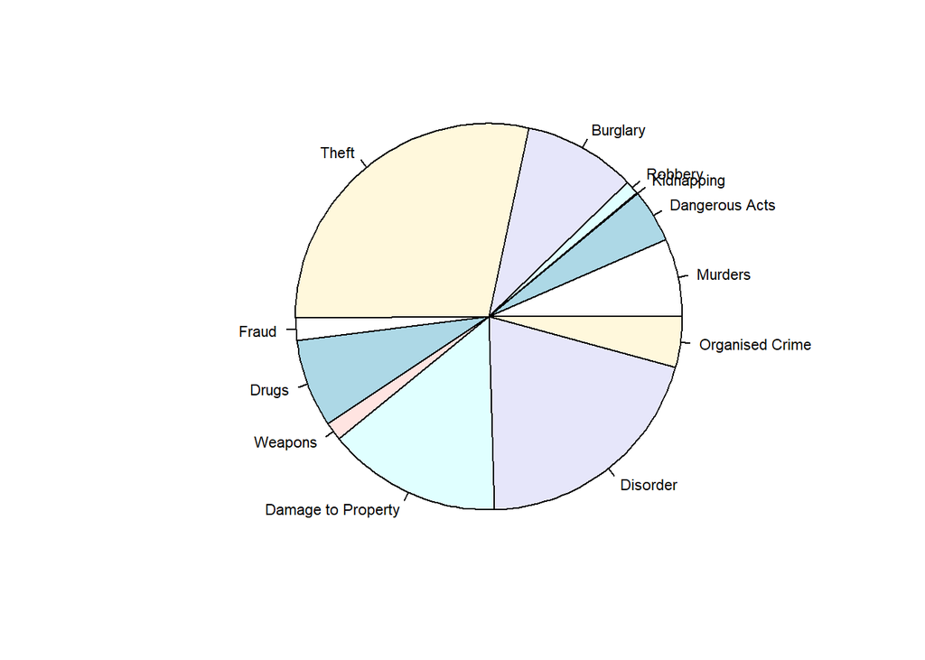

## Inferential Statistics

- Is there a significant difference in the murder rates in counties with high drug use versus low drug use
- Is there more damages to the property or more burglary(make hypothesis)
- Do areas with higher rate assault/murder have a larger ratio of burglaries to property damage?